# CFRM 502, Winter 2020

# Instructor: Bahman Angoshtari

# Lectures 12

**Chapter 14:** GARCH, ARIMA+GARCH, IGARCH, GARCH-M

```r
# Setting parameters of the Jupyter notebook
sc = .75
options(repr.plot.width=16*sc,
        repr.plot.height=7*sc,
        repr.plot.pointsize = 13, # Text height in pt
        repr.plot.bg        = 'white',
        repr.plot.antialias = 'gray',
        #nice medium-res DPI
        repr.plot.res       = 300,
        #jpeg quality bumped from default
        repr.plot.quality   = 90,
        #vector font family
        repr.plot.family    = 'serif')
# Vector font family. 'sans', 'serif', 'mono' or a specific one
```

$\newcommand{\1}{{\bf 1}}$ $\newcommand\Fc{\mathscr{F}}$ $\newcommand{\eps}{\varepsilon}$ $\newcommand{\Var}{\operatorname{Var}}$ $\newcommand\Cov{\operatorname{Cov}}$ $\newcommand\Corr{\operatorname{Corr}}$ $\newcommand{\sig}{\sigma}$ $\newcommand\Sig{\Sigma}$ $\newcommand{\al}{\alpha}$ $\newcommand{\gam}{\gamma}$ $\newcommand\Gam{\Gamma}$ $\newcommand\lam{\lambda}$ $\newcommand{\Del}{\Delta}$ $\newcommand{\del}{\delta}$ $\newcommand\tht{\theta}$ $\newcommand\ph{\varphi}$ $\newcommand\om{\omega}$ $\newcommand\Om{\Omega}$ $\newcommand\rb{\bar{r}}$ $\newcommand{\Xb}{\bar{X}}$ $\newcommand{\Yb}{\bar{Y}}$ $\newcommand\Eb{\mathbb{E}}$ $\newcommand\Pb{\mathbb{P}}$ $\newcommand\Qb{\mathbb{Q}}$ $\newcommand\Rb{\mathbb{R}}$ $\newcommand\Zb{\mathbb{Z}}$ $\newcommand\Nb{\mathbb{N}}$ $\newcommand\Av{\textbf{A}}$ $\newcommand\Ev{\textbf{E}}$ $\newcommand\Dv{\textbf{D}}$ $\newcommand\Fv{\textbf{F}}$ $\newcommand\Gv{\textbf{G}}$ $\newcommand\Hv{\textbf{H}}$ $\newcommand\Kv{\textbf{K}}$ $\newcommand\Iv{\textbf{I}}$ $\newcommand\Pv{\textbf{P}}$ $\newcommand\Ov{\textbf{O}}$ $\newcommand\Sv{\textbf{S}}$ $\newcommand\Xv{\textbf{X}}$ $\newcommand\Yv{\textbf{Y}}$ $\newcommand\Zv{\textbf{Z}}$ $\newcommand\av{\mathbf{a}}$ $\newcommand\xv{\mathbf{x}}$ $\newcommand\yv{\mathbf{y}}$ $\newcommand\zv{\mathbf{z}}$ $\newcommand\Cv{\mathbf{C}}$ $\newcommand\mv{\mathbf{m}}$ $\newcommand\nv{\mathbf{n}}$ $\newcommand\pv{\mathbf{p}}$ $\newcommand\sv{\mathbf{s}}$ $\newcommand\wv{\mathbf{w}}$ $\newcommand\Wv{\textbf{W}}$ $\newcommand\alv{{\boldsymbol\al}}$ $\newcommand\betav{{\boldsymbol\beta}}$ $\newcommand\etav{{\boldsymbol\eta}}$ $\newcommand\epsv{{\boldsymbol\varepsilon}}$ $\newcommand\delv{{\boldsymbol\delta}}$ $\newcommand\Lamv{{\boldsymbol\Lambda}}$ $\newcommand\lamv{{\boldsymbol\lambda}}$ $\newcommand\muv{{\boldsymbol\mu}}$ $\newcommand\piv{{\boldsymbol\pi}}$ $\newcommand\Piv{{\boldsymbol\Pi}}$ $\newcommand\Gamv{{\boldsymbol\Gam}}$ $\newcommand\Phiv{{\boldsymbol\Phi}}$ $\newcommand\Sigv{{\boldsymbol\Sig}}$ $\newcommand\ah{\widehat{a}}$ $\newcommand\Pbh{\widehat{\Pb}}$ $\newcommand\phh{\widehat{\varphi}}$ $\newcommand\Ebh{\widehat{\Eb}}$ $\newcommand\Qh{\widehat{Q}}$ $\newcommand\Ih{\widehat{I}}$ $\newcommand\rh{\widehat{r}}$ $\newcommand\pih{\widehat{\pi}}$ $\newcommand\Pih{\widehat{\Pi}}$ $\newcommand\Sigvh{\widehat{\Sigv}}$ $\newcommand\Wh{\widehat{W}}$ $\newcommand\Fh{\widehat{F}}$ $\newcommand\Yh{\widehat{Y}}$ $\newcommand\Zh{\widehat{Z}}$ $\newcommand\Yvh{\widehat{\Yv}}$ $\newcommand\Ah{\widehat{\Ac}}$ $\newcommand\uh{\widehat{u}}$ $\newcommand\vh{\widehat{v}}$ $\newcommand\fh{\widehat{f}}$ $\newcommand\hh{\widehat{h}}$ $\newcommand\Bh{\widehat{B}}$ $\newcommand\Ovh{\widehat{\Ov}}$ $\newcommand\Xvh{\widehat{\Xv}}$ $\newcommand\rhoh{\widehat{\rho}}$ $\newcommand\omh{\widehat{\om}}$ $\newcommand\nuh{\widehat{\nu}}$ $\newcommand\varphih{\widehat{\varphi}}$ $\newcommand\alh{\widehat{\al}}$ $\newcommand\thetah{\widehat{\theta}}$ $\newcommand\betah{\widehat{\beta}}$ $\newcommand\betavh{\widehat{\boldsymbol\beta}}$ $\newcommand\kaph{\widehat{\kappa}}$ $\newcommand\sigh{\widehat{\sigma}}$ $\newcommand\epsh{\widehat{\eps}}$ $\newcommand\epsvh{\widehat{\epsv}}$ $\newcommand\epst{\widetilde{\eps}}$ $\newcommand\muh{\widehat{\mu}}$ $\newcommand\dd{\mathrm{d}}$ $\newcommand\ee{\mathrm{e}}$

# 0. Overview of the lecture

- In this lecture, we study more volatility models.
- We start with GARCH models that generalize ARCH models (the same way that ARMA generalizes AR)
- We then consider mixed ARIMA + GARCH model, where the mean equation is ARIMA with error that is described by GARCH
- After this, we study several extensions of GARCH models that are developed to explain behaviors of financial return time series that the standard GARCH model cannot explain:
  - IGARCH: persistence of volatility shocks
  - GARCH-M: risk premium
  - EGARCH, TGARCH, APARCH: the leverage effect (Lecture 13)

# 1. Generalized ARCH (GARCH) models

- ARCH processes can be very restrictive. You may need a high order ARCH process to properly fit a time series.
- The situation is similar to what we faced with AR(p) models. To find more parsimonious models, we extended AR to ARMA.
- In the same way, GARCH models extend ARCH.
- If $\{a_t\}$ is a GARCH(p,q) model, then $\{a_t^2\}$ is an ARMA(p,q) process
- $\{a_t\}$ is a GARCH(p,q) process if, for $t=1,2,\dots$,

\begin{align*} \begin{cases} a_t = \sig_t\,\eps_t,\quad \eps_t\overset{i.i.d.}{\sim} F_\eps,\\ \sig_t^2 = \om + \al_1\,a_{t-1}^2 + \dots + \al_p\,a_{t-p}^2 + \beta_1\,\sig_{t-1}^2 + \dots + \beta_q\,\sig_{t-q}^2. \end{cases} \end{align*}

- At $t=0$, we assume that $a_{0}, a_{-1}, \dots, a_{-p}$ are known and $\sig_{-1}^2, \sig_{-2}^2, \dots, \sig_{-q}^2$ are unknown random variables.
- As in the ARCH specification, $F_\eps$ is any distribution function such that $\Eb(\eps_t)=0$ and $\Var(\eps_t)=1$
- We assume $\om>0$, and $\al_i,\beta_j\ge0$
- Under additional conditions, $\{a_t\}$ are weak white noise. However, $\{a_t\}$ is serially dependent and shows variance clustering
- To obtain ARMA form of $\{a_t^2\}$, we define $\eta_t = a_t^2-\sig_t^2$
- It can be shown that $\{\eta_t\}$ is a weak white noise
- By some calculations, one can show that

\begin{align*} a_t^2 = \om + \sum_{i=1}^{\max(p,q)} (\al_i+\beta_i) a_{t-i}^2 + \eta_t -\sum_{j=1}^q \beta_j \eta_{t-j} \end{align*}

- Here, if $p>q$ (respectively $p<q$), we define $\beta_{q+1}=\dots =\beta_{p}=0$ (respectively, $\al_{p+1}=\dots =\al_{q}=0$)

## 1.1. GARCH(1,1)

- To better understand properties of GARCH(p,q) models, let us focus on GARCH(1,1)

\begin{align*} \begin{cases} a_t = \sig_t\,\eps_t,\quad \eps_t\overset{i.i.d.}{\sim} F_\eps,\\ \sig_t^2 = \om + \al_1\,a_{t-1}^2 + \beta_1\,\sig_{t-1}^2. \end{cases} \end{align*}

- Let $\eta_t:=$ $a_t^2-$ $\sig_t^2$, then

\begin{align*} a_t^2 = \om + (\al_1+\beta_1) a_{t-1}^2 + \eta_t - \beta_1 \eta_{t-1}. \end{align*}

- $\{a_t\}$ is weakly stationary if $\om\ge0,\al_1\ge0, \beta_1\le 1,$ and $\al_1+\beta_1<1$.
- Volatility of $\{a_t\}$ clusters as in ARCH(1)
- If $1-2\al_1^2$ $-(\al_1$ $+\beta_1)^2$ $>0$, then the kurtosis of $a_t$ is

\begin{align*} \frac{\Eb(a_t^4)}{\big(\Eb(a_t^2)\big)^2} = \frac{3 \big(1-(\al_1+\beta_1)^2\big)}{1-2\al_1^2-(\al_1+\beta_1)^2}>3 \end{align*}

- That is, the distribution of $a_t$ has heavier tails than the normal distribution
- Next, let us find forecasts of volatility $\sig_t$.
- For finding the 1-step-ahead forecast, we write the volatility equation for $\sig_{t+1}^2$

\begin{align*} \sig_{t+1}^2 = \om + \al_1 a_t^2 + \beta_1 \sig_t^2. \end{align*}

- So, the 1-step-ahead forecast for $\sig_{t+1}^2$ given $a_t, a_{t-1}, a_{t-2},...$ is

\begin{align*} \sigh_{t}^2(1) = \omh + \alh_1 a_t^2 + \betah_1 \sigh_t^2. \end{align*}

- Here, $\alh_1$ and $\beta_1$ are estimates of $\al$ and $\beta$ (given $a_t, a_{t-1}, a_{t-2},...$).
- Furthermore, $\sigh_t, \sigh_{t-1}, \dots, \sigh_{1}$ are calculated recursively using

\begin{align*} \sigh_t^2 = \omh + \alh_1\,a_{t-1}^2 + \betah_1\,\sigh_{t-1}^2 \end{align*}

- To find 2-step-ahead forecast, we first replace $a_{t+1}^2=\sig_{t+1}^2\eps_{t+1}^2$ in the volatility equation

\begin{align*} \sig_{t+2}^2 &= \om + \al_1 a_{t+1}^2 + \beta_1 \sig_{t+1}^2\\\\ &= \om + \al_1 \sig_{t+1}^2 \eps_{t+1}^2 \color{red}{- \al_1 \sig_{t+1}^2 + \al_1 \sig_{t+1}^2} + \beta_1 \sig_{t+1}^2\\\\ &= \om + \al_1 \sig_{t+1}^2 (\eps_{t+1}^2-1) + (\al_1+\beta_1) \sig_{t+1}^2 \end{align*}

- Noting that $\Eb(\eps_{t+1}^2$ $|a_{t},a_{t-1}$ $,\dots) = $ $\Eb($ $\eps_{t+1}^2)=$ $\Var(\eps_{t+1}$ $)=1$, we obtain

\begin{align*} \sigh_t^2(2) &= \omh + (\alh_1+\betah_1) \sigh_t^2(1) \end{align*}

- Using a similar argument, we have for all $h\ge2$,

\begin{align*} \sigh_t^2(h) &= \omh + (\alh_1+\betah_1) \sigh_t^2(h-1) \end{align*}

- Compare this result with the multi-step-ahead forecasts of an ARMA(1,1) model (Question 1.(a) of Homework 5)

## 2. Fitting ARIMA+GARCH models

- An ARIMA+GARCH model is a time series model in which the mean equation is specified by an ARIMA model while the innovations (that is the error in the eqution for the time series) are specified by a GARCH model
- Let us illustrate by using the DJI example from the previous lecture (note that now, we are looking at a longer time-series starting at Jan. 2007)

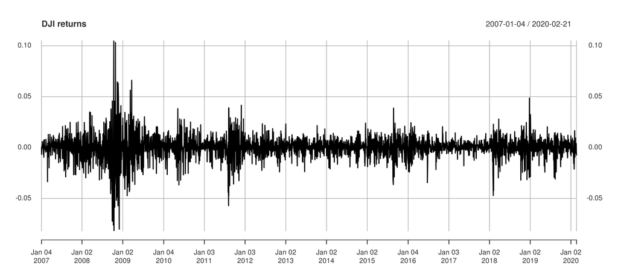

```r
library("quantmod")
DJI = getSymbols("^DJI", src="yahoo", auto.assign=FALSE)$DJI.Adjusted
rtn = na.omit(diff(log(DJI)))
plot(rtn, type="l", col=1, main = "DJI returns")
```

- The returns are stationary, but not weak WN

```
	KPSS Test for Level Stationarity

data:  rtn
KPSS Level = 0.22247, Truncation lag parameter = 9, p-value = 0.1
```

```
	Box-Ljung test

data:  rtn
X-squared = 57.251, df = 5, p-value = 4.489e-11
```

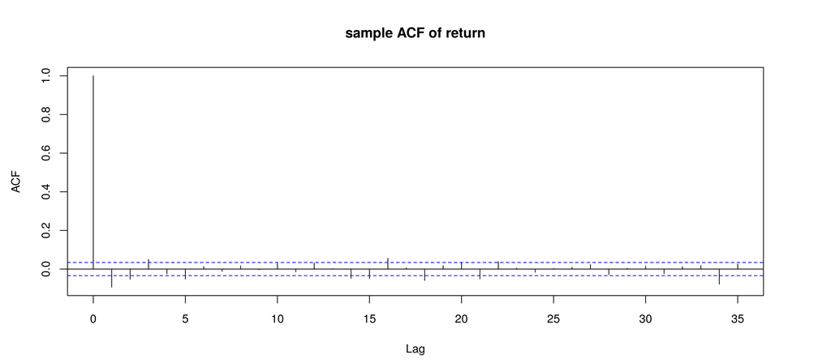

```r
library(tseries)
par(mar=c(4.5,4.5,4.5,4.5))
acf(as.numeric(rtn), main="sample ACF of return")
kpss.test(rtn)
Box.test(rtn, lag = 5, type = "Ljung-Box")
```

- Let us start by identifying the mean equation
- `auto.arima()` indicates an MA(1) model (we will check the adequecy of this model later)

```r
library(forecast)
fit=auto.arima(rtn, max.p = 20, max.q = 20, max.d = 2, ic="bic")
print(fit)
```

```
Series: rtn
ARIMA(0,0,1) with zero mean

Coefficients:
          ma1
      -0.1034
s.e.   0.0180

sigma^2 estimated as 0.0001269:  log likelihood=10140.28
AIC=-20276.56   AICc=-20276.56   BIC=-20264.36
```

- The model doesn't look adequate. We decide to go ahead, nonetheless (we can justify doing so by the low BIC of the MA(1) model).

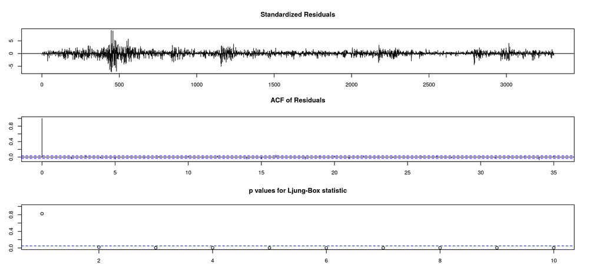

```r
par(mar=c(2,3,4,4))
tsdiag(fit)
```

```r
tsdiag_vol = function(model, lag, fitdf, span=0.5){
    par(mfrow=c(1,2));par(mar=c(3,3,3,3))
    plot(resid(model)**2, type="l", col=1,
         main = expression(residual^2))
    smoother = loess((resid(model)**2) ~ seq(1,length(resid(model))),
                     span=span)
    lines(seq(1,length(resid(model))),fitted(smoother),col=2)
    acf((resid(model)**2), main=expression("sample ACF of "~ residual^2))
    Box.test(resid(model)**2, lag = lag, type = "Ljung-Box", fitdf = fitdf)
}
tsdiag_norm = function(model){
    qqnorm(resid(model), datax = FALSE,
       xlab = "normal quantile",
       ylab = "sample quantile of residuals",
       main = "normal probability plot for residuals")
    qqline(resid(model), datax=FALSE, col = 2)
    shapiro.test(resid(model))
}
```

- Next, we test for the ARCH effect in the residuals of the MA(1) model. The volatility is not constant.

```
	Box-Ljung test

data:  resid(model)^2
X-squared = 3676.3, df = 11, p-value < 2.2e-16
```

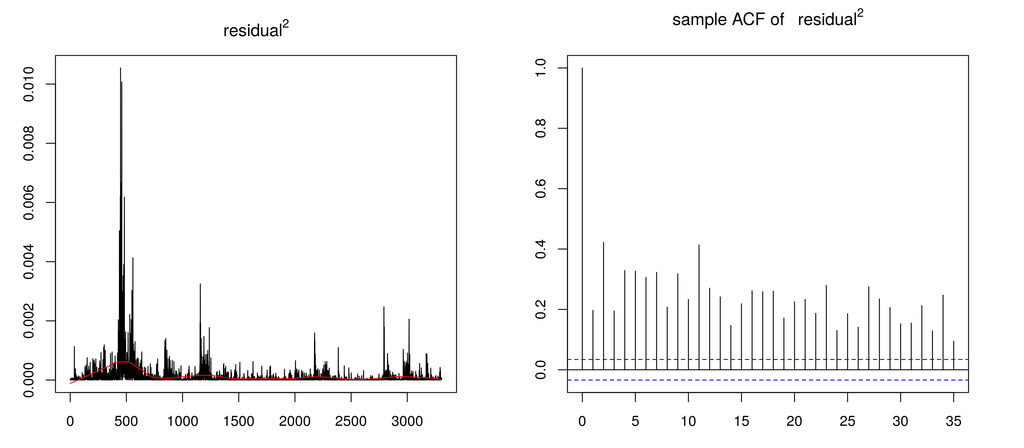

```r
tsdiag_vol(fit, lag=12, fitdf=1, span=0.25)
```

- First, we consider an ARCH(p) model for the errors.
- The PACF of the squared returns indicate ARCH order of 14 (at least).
- We should consider GARCH to get a more parsimonous model

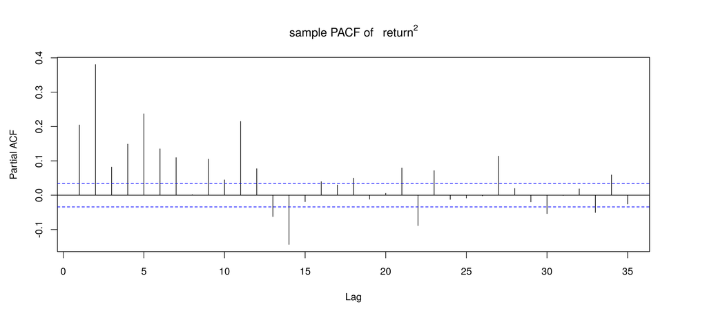

```r
par(mar=c(4.5,4.5,4.5,4.5))
pacf(as.numeric(rtn**2), main=expression("sample PACF of "~ return^2))
```

- The test statistics show that the ARIMA+GARCH specification is adequet, thought the normality assumption does not hold

```r
library(fGarch)
fit_magarch = garchFit(~arma(0,1)+garch(1,1), data=rtn, trace = F)
summary(fit_magarch)
```

```
Title:
 GARCH Modelling

Call:
 garchFit(formula = ~arma(0, 1) + garch(1, 1), data = rtn, trace = F)

Mean and Variance Equation:
 data ~ arma(0, 1) + garch(1, 1)
<environment: 0x5613affb5738>
 [data = rtn]

Conditional Distribution:
 norm

Coefficient(s):
         mu          ma1        omega       alpha1        beta1
 7.2065e-04  -5.4836e-02   2.5926e-06   1.4209e-01   8.3627e-01

Std. Errors:
 based on Hessian

Error Analysis:
         Estimate  Std. Error  t value Pr(>|t|)
mu      7.206e-04   1.210e-04    5.954 2.61e-09 ***
ma1    -5.484e-02   1.918e-02   -2.859  0.00425 **
omega   2.593e-06   3.699e-07    7.009 2.40e-12 ***
alpha1  1.421e-01   1.348e-02   10.542  < 2e-16 ***
beta1   8.363e-01   1.334e-02   62.666  < 2e-16 ***
---
Signif. codes:  0 ‘***’ 0.001 ‘**’ 0.01 ‘*’ 0.05 ‘.’ 0.1 ‘ ’ 1

Log Likelihood:
 10983.33    normalized:  3.322241

Description:
 Mon Feb 24 12:48:30 2020 by user: bahman


Standardised Residuals Tests:
                                Statistic p-Value
 Jarque-Bera Test   R    Chi^2  637.1483  0
 Shapiro-Wilk Test  R    W      0.9764694 0
 Ljung-Box Test     R    Q(10)  12.5864   0.2477247
 Ljung-Box Test     R    Q(15)  24.84744  0.05203014
 Ljung-Box Test     R    Q(20)  27.85752  0.1128154
 Ljung-Box Test     R^2  Q(10)  9.681367  0.4688786
 Ljung-Box Test     R^2  Q(15)  13.73546  0.5456801
 Ljung-Box Test     R^2  Q(20)  16.25287  0.7008177
 LM Arch Test       R    TR^2   10.75124  0.5503492

Information Criterion Statistics:
      AIC       BIC       SIC      HQIC
-6.641458 -6.632227 -6.641462 -6.638154
```

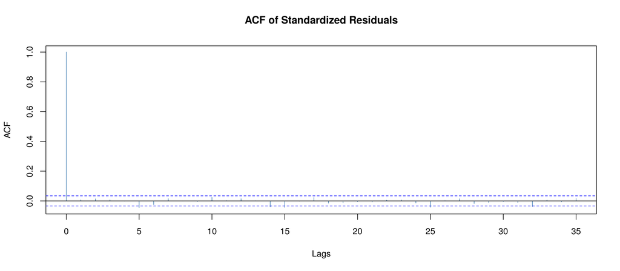

```r
plot(fit_magarch, which=10)
```

- The ACF plot of the squared standardized residual shows that the GARC(1,1) specification is adequate. So do the Ljung-Box tests of standardized residuals$^2$.

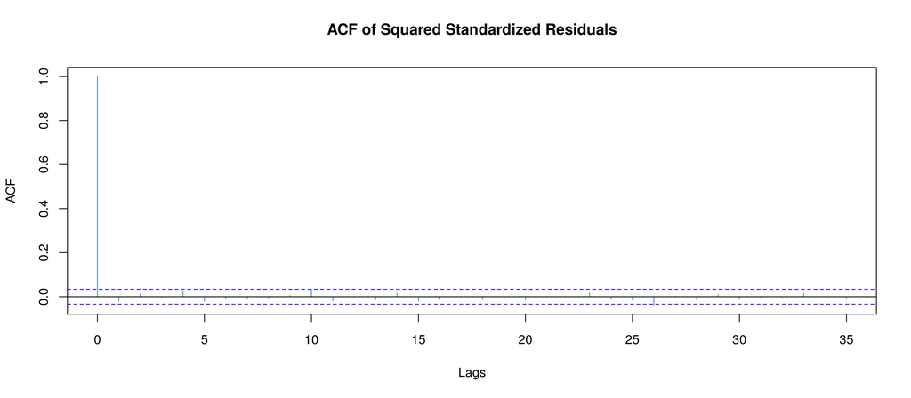

```r
plot(fit_magarch, which=11)
```

- The normal probability plot of the standardized residuals indicates fat-tailed distribution (as expected)

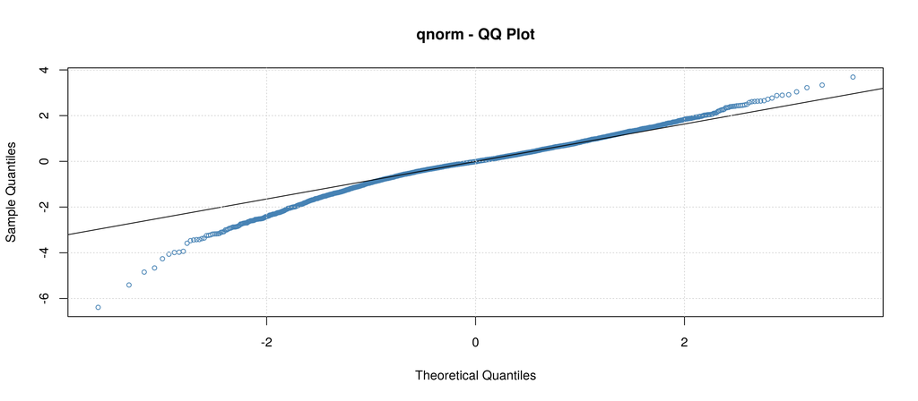

```r
plot(fit_magarch, which=13)
```

```r
fit_magarch_tdist = garchFit(~arma(0,1)+garch(1,1), data=rtn,
                             cond.dist = "std",trace = F)
summary(fit_magarch_tdist)
```

```
Title:
 GARCH Modelling

Call:
 garchFit(formula = ~arma(0, 1) + garch(1, 1), data = rtn, cond.dist = "std",
    trace = F)

Mean and Variance Equation:
 data ~ arma(0, 1) + garch(1, 1)
<environment: 0x5613aca825a0>
 [data = rtn]

Conditional Distribution:
 std

Coefficient(s):
         mu          ma1        omega       alpha1        beta1        shape
 8.3694e-04  -5.4432e-02   1.6847e-06   1.4659e-01   8.5209e-01   5.0208e+00

Std. Errors:
 based on Hessian

Error Analysis:
         Estimate  Std. Error  t value Pr(>|t|)
mu      8.369e-04   1.083e-04    7.727 1.11e-14 ***
ma1    -5.443e-02   1.753e-02   -3.105   0.0019 **
omega   1.685e-06   3.954e-07    4.260 2.04e-05 ***
alpha1  1.466e-01   1.758e-02    8.339  < 2e-16 ***
beta1   8.521e-01   1.537e-02   55.441  < 2e-16 ***
shape   5.021e+00   4.782e-01   10.499  < 2e-16 ***
---
Signif. codes:  0 ‘***’ 0.001 ‘**’ 0.01 ‘*’ 0.05 ‘.’ 0.1 ‘ ’ 1

Log Likelihood:
 11083.45    normalized:  3.352526

Description:
 Mon Feb 24 12:48:39 2020 by user: bahman


Standardised Residuals Tests:
                                Statistic p-Value
 Jarque-Bera Test   R    Chi^2  796.3694  0
 Shapiro-Wilk Test  R    W      0.9747495 0
 Ljung-Box Test     R    Q(10)  12.87167  0.2309358
 Ljung-Box Test     R    Q(15)  25.1678   0.04773477
 Ljung-Box Test     R    Q(20)  28.32873  0.1018432
 Ljung-Box Test     R^2  Q(10)  8.775243  0.5535585
 Ljung-Box Test     R^2  Q(15)  14.91769  0.4573624
 Ljung-Box Test     R^2  Q(20)  19.33859  0.499925
 LM Arch Test       R    TR^2   10.75531  0.5499969

Information Criterion Statistics:
      AIC       BIC       SIC      HQIC
-6.701422 -6.690345 -6.701429 -6.697457
```

- The t-plot of the standardized residuals is a much better fit. Although, there might be some skewness in the residuals

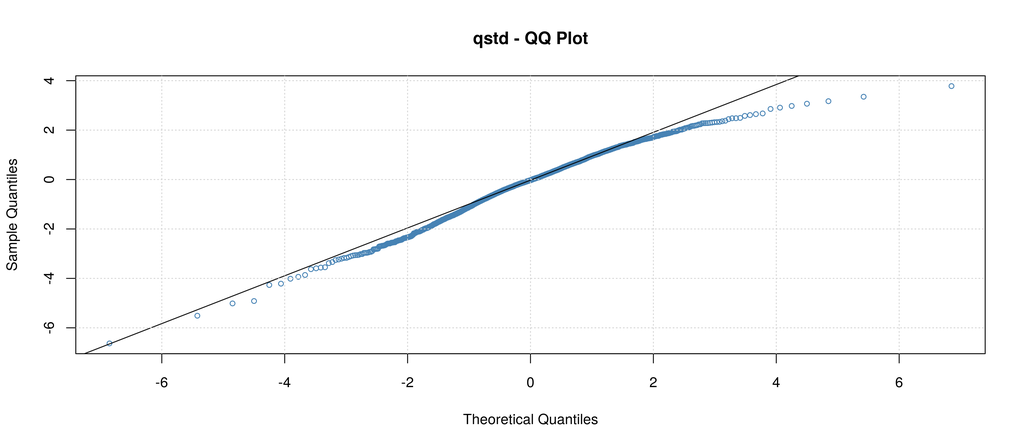

```r
plot(fit_magarch_tdist, which=13)
```

- We can get in-sample estimates of $\sig_t^2$ easily. These are estimates of $\sig_t^2$ given $r_1,\dots, r_T$ for **$t\le T$**.
- For a model fitted with `garchFit`, we can access in-sample estimates of the volatility using `@sigma.t` or `volatility()`. You can get a time series plot with fitted twice volatility by passing `which=3` to the `plot()`

```r
head(fit_magarch_tdist@sigma.t)
```

1. 0.0113565490662293

2. 0.0105631209885759

3. 0.0102454985066907

4. 0.0095511512312791

5. 0.00892649277526685

6. 0.00835305964164479

```r
head(volatility(fit_magarch_tdist))
```

1. 0.0113565490662293

2. 0.0105631209885759

3. 0.0102454985066907

4. 0.0095511512312791

5. 0.00892649277526685

6. 0.00835305964164479

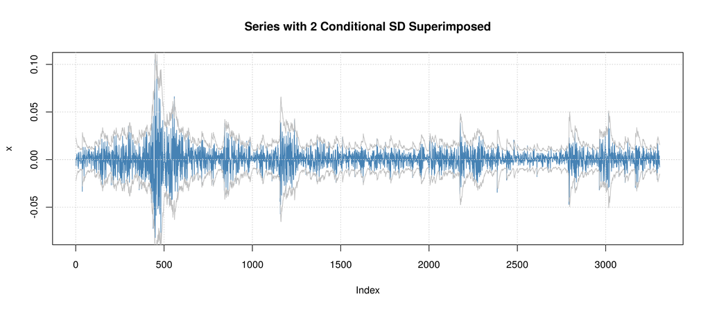

```r
plot(fit_magarch_tdist, which=3)
```

- We can also find out-of-sample estimate of conditional volatility.

```r
predict(fit_magarch_tdist,6)
```

A data.frame: 6 × 3

| meanForecast <dbl> | meanError <dbl> | standardDeviation <dbl> |
| --- | --- | --- |
| 0.0013230802 | 0.007990522 | 0.007990522 |
| 0.0008369445 | 0.008101734 | 0.008090050 |
| 0.0008369445 | 0.008200072 | 0.008188239 |
| 0.0008369445 | 0.008297118 | 0.008285138 |
| 0.0008369445 | 0.008392915 | 0.008380790 |
| 0.0008369445 | 0.008487507 | 0.008475239 |

- These predictions can be used for out-of-sample performance measurement.
- There is a slight difference between out-of-sample error for volatility and that of the mean. In particular, what is the observed value of vol?

# 3. Extensions of GARCH model

- Next, we discuss some extensions of the GARCH model.
- These models have been proposed to explain the characteristics of time series for which simple GARCH models are not appropriate
- Specifically, we are interested in measuring the following characteristics of financial returns
  - **Persistence shocks to vol:** IGARCH
  - **Risk premium:** GARCH-M
  - **Leverage effect:** EGARCH, TGARCH, APARCH (Lecture 13)

## 3.1. Integrated GARCH (IGARCH)

- An IGARCH(p,q) model is a GARCH(p,q) model in which the ARMA model for $\{a_t^2\}$ has a unit root

\begin{align*} a_t^2 = \om + \sum_{i=1}^{\max(p,q)} (\al_i+\beta_i) a_{t-i}^2 + \eta_t -\sum_{j=1}^q \beta_j \eta_{t-j} \end{align*}

- In other words, the characteristic polynomial has complex root with $|x|\le 1$

\begin{align*} 1 - \sum_{i=1}^{\max(p,q)} (\al_i+\beta_i) x^i=0 \end{align*}

- Recall that changes in the mean of ARIMA(p,1,q) processes are persistent
- In a similar way, the impact of past volatility shocks in IGARCH(p,q) models is **persistent**. This is the key feature of IGARCH model.
- Consider an IGARCH(1,1) model

\begin{align*} \begin{cases} a_t = \sig_t\,\eps_t,\quad \eps_t\overset{i.i.d.}{\sim} F_\eps,\\ \sig_t^2 = \om + (1-\beta_1)\,a_{t-1}^2 + \beta_1\,\sig_{t-1}^2. \end{cases} \end{align*}

- Here, we assume $0<\beta_1<1$.
- Does the characteristic equation for the ARMA model of $\{a_t^2\}$ has a unit root?
- Major difference between GARCH and IGARCH: the **unconditional variance** of an IGARCH process is **not defined**
- Because IGARCH processes do not have second moment, they cannot be **weakly stationary**!
- However, under additional conditions, they are **strictly stationary**
- The same is true for the volatility process $\{\sig_t\}$ of an IGARCH process. It is not weakly stationary since it does not have the first two moments. However, under additional conditions, they are strictly stationary
- Forecasting for IGARCH models is similar to GARCH
- Consider the case of IGARCH(1,1)
- Repeating the argument for multi-step-ahead forecasts of simple GARCH(1,1) yield, for $h\ge2$

\begin{align*} \sigh_t^2(h) &= \omh + (1-\betah_1+\betah_1) \sigh_t^2(h-1)\\\\ &= \omh + \sigh_t^2(h-1)\\\\ &= \omh + \omh + \sigh_t^2(h-2) = \dots = (h-1)\omh + \sigh_t^2(1) \end{align*}

- The $h$-step-ahead vol forecast is a linear function of forecast horizon $h$ with slope $\omh$
- If $\om=0$, then the multi-step-ahead vol forecast are constant (not changing with the forecast horizon $h$). This property is used in **RiskMetrics** which is the benchmark model for calculating **Value-at-Risk**
- Let us consider monthly excess return of S&P 500. The data is in the text file "m-SP500.txt" which accompanies this lecture notes.

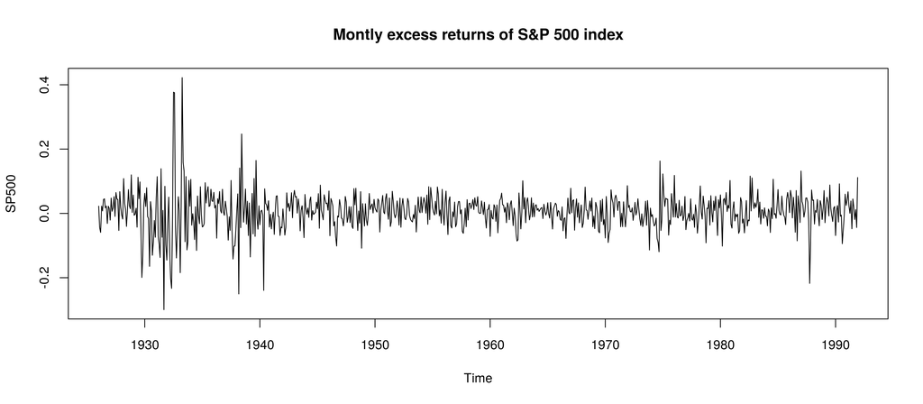

```r
rtn = ts(read.table("m-SP500.txt", header=TRUE), start=c(1926,1), frequency=12)
plot(rtn, main="Montly excess returns of S&P 500 index")
```

- `auto.arima()` suggests an MA(1) model for the mean equation.

```r
library(forecast)
fit=auto.arima(rtn, max.p = 20, max.q = 20, max.d = 2, ic="bic")
print(fit)
```

```
Series: rtn
ARIMA(0,0,1) with non-zero mean

Coefficients:
         ma1    mean
      0.0926  0.0061
s.e.  0.0351  0.0023

sigma^2 estimated as 0.003393:  log likelihood=1128.88
AIC=-2251.76   AICc=-2251.73   BIC=-2237.74
```

- The mean equation of MA(1) does not seem adequate. We nonetheless use it as a parsimonious model.

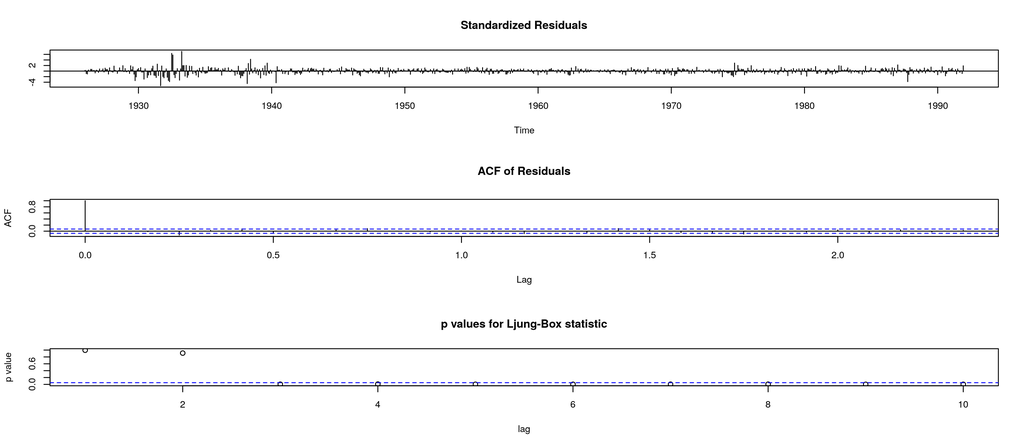

```r
tsdiag(fit)
```

- The sample ACF plot of residuals$^2$ indicates ARCH effect
- Both ACF and PACF of residuals$^2$ need high GARCH order. That is, the affect of shocks to vol seems persistent. To get a parsimonious model, we may try an IGARCH(1,1) model.

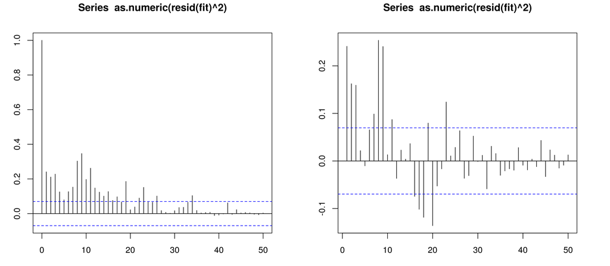

```r
par(mfrow=c(1,2));par(mar=c(3,3,3,3))
acf(as.numeric(resid(fit)**2), lag.max=50)
pacf(as.numeric(resid(fit)**2), lag.max=50)
```

- We use the `rugarch` package to fit MA+IGARCH model. This package is similar to `fGarch`, and is capable of fitting ARFIMA + several variations of GARCH model.
- The fitted model is

\begin{align*} \begin{cases} r_t - 0.007431 = a_t + 0.035311 a_{t-1},\\ a_t = \sig_t\,\eps_t,\quad \eps_t\overset{i.i.d.}{\sim} N(0,1),\\ \sig_t^2 = 0.000051 + 0.142869\,a_{t-1}^2 + 0.857131\,\sig_{t-1}^2. \end{cases} \end{align*}

- Model diagnostic is as before. The mean and volatility equations seem adequate. The standardized residuals seem normally distributed.

```r
library(rugarch)
spec = ugarchspec(variance.model=list(model="iGARCH", garchOrder=c(1,1)),
                  mean.model=list(armaOrder=c(0,1)))
fit_igarch = ugarchfit(data=rtn, spec=spec)
show(fit_igarch)
```

```
*---------------------------------*
*          GARCH Model Fit        *
*---------------------------------*

Conditional Variance Dynamics
-----------------------------------
GARCH Model	: iGARCH(1,1)
Mean Model	: ARFIMA(0,0,1)
Distribution	: norm

Optimal Parameters
------------------------------------
        Estimate  Std. Error  t value Pr(>|t|)
mu      0.007431    0.001572  4.72808 0.000002
ma1     0.035311    0.039522  0.89347 0.371607
omega   0.000051    0.000017  2.91936 0.003507
alpha1  0.142869    0.021434  6.66544 0.000000
beta1   0.857131          NA       NA       NA

Robust Standard Errors:
        Estimate  Std. Error  t value Pr(>|t|)
mu      0.007431    0.001619  4.58862 0.000004
ma1     0.035311    0.040302  0.87616 0.380942
omega   0.000051    0.000019  2.70950 0.006739
alpha1  0.142869    0.024462  5.84032 0.000000
beta1   0.857131          NA       NA       NA

LogLikelihood : 1268.635

Information Criteria
------------------------------------

Akaike       -3.1935
Bayes        -3.1699
Shibata      -3.1936
Hannan-Quinn -3.1844

Weighted Ljung-Box Test on Standardized Residuals
------------------------------------
                        statistic p-value
```

[output cut: 38 more lines]

```
Negative Sign Bias  1.3484 0.1779332
Positive Sign Bias  0.8413 0.4004438
Joint Effect       19.9421 0.0001745 ***


Adjusted Pearson Goodness-of-Fit Test:
------------------------------------
  group statistic p-value(g-1)
1    20     29.01      0.06583
2    30     38.15      0.11900
3    40     42.95      0.30576
4    50     54.46      0.27441


Elapsed time : 0.05813122
```

```
please wait...calculating quantiles...
```

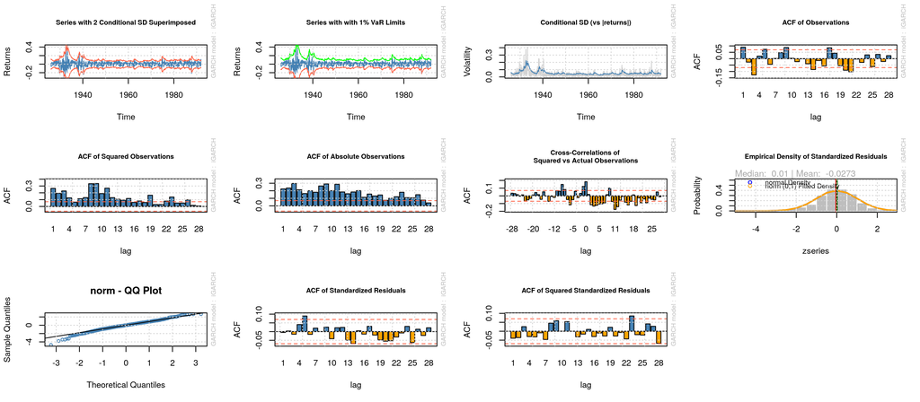

```r
plot(fit_igarch, which="all")
```

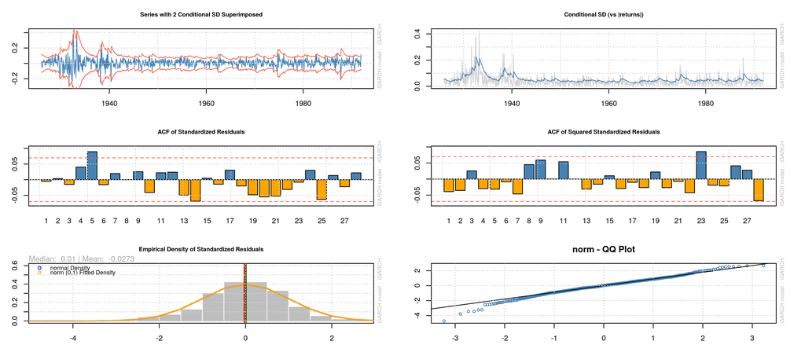

```r
par(mfrow=c(3,2));par(mar=c(3,3,3,3))
plot(fit_igarch,which=1)
plot(fit_igarch,which=3)
plot(fit_igarch,which=10)
plot(fit_igarch,which=11)
plot(fit_igarch,which=8)
plot(fit_igarch,which=9)
```

## 3.2. GARCH in the mean (GARCH-M)

- It is generally accepted that the return of a financial assets depends on its volatility
- Justification: Volatility is interpreted as a measure of risk in investing in an asset. Therefore, assets with higher volatility should have higher returns to compensate for their higher risk. The additional expected return (over, say, a risk-free asset) is called the **risk premium**
- This justification is not completely accurate, actually. Only risk that cannot be diversified away (i.e. by investing in other assets) should be compensated. Pure gambling does not contribute to risk premium! (More on this when we study factor models.)
- The GARCH-M model considers a mean equation of the form

\begin{align*} r_t = \mu + c\,g(\sig_t) + a_t \end{align*}

- Here, the parameter $c$ is referred to as the **risk premium** and is expected to be positive.
- Two common choices for the function $g(\cdot)$ is $g(\sig)=\sig$ and $g(\sig)=\sig^2$.
- The volatility equation for $\sig_t^2$ can a GARCH, IGARCH, etc.
- Let us fit a GARCH(1,1)-M model to monthly excess return of S&P 500 time series.
- We can use `archm=TRUE` and `archpow=2` (respectively, `archpow=1`) to add a GARCH-M term $c\,\sig_t^2)$ (respectively, $c\,\sig_t^2)$) to the mean equation.

\begin{align*} \begin{cases} r_t = 0.005421 + 1.007914\, \sig_t^2 + a_t,\\ a_t = \sig_t\,\eps_t,\quad \eps_t\overset{i.i.d.}{\sim} N(0,1),\\ \sig_t^2 = 0.000083 + 0.123119\,a_{t-1}^2 + 0.852274\,\sig_{t-1}^2. \end{cases} \end{align*}

- The estimated risk-premium is 1.007914. However, it is statistically insignificant.

```r
spec = ugarchspec(variance.model=list(garchOrder=c(1,1)),
                  mean.model=list(armaOrder=c(0,0),
                                  archm=TRUE, archpow=2))
fit_garchm = ugarchfit(data=rtn, spec=spec)
show(fit_garchm)
```

```
*---------------------------------*
*          GARCH Model Fit        *
*---------------------------------*

Conditional Variance Dynamics
-----------------------------------
GARCH Model	: sGARCH(1,1)
Mean Model	: ARFIMA(0,0,0)
Distribution	: norm

Optimal Parameters
------------------------------------
        Estimate  Std. Error  t value Pr(>|t|)
mu      0.005421    0.002360   2.2968 0.021628
archm   1.007914    0.888456   1.1345 0.256604
omega   0.000083    0.000029   2.8294 0.004664
alpha1  0.123119    0.022285   5.5247 0.000000
beta1   0.852274    0.022397  38.0527 0.000000

Robust Standard Errors:
        Estimate  Std. Error  t value Pr(>|t|)
mu      0.005421    0.002440   2.2220 0.026282
archm   1.007914    0.891197   1.1310 0.258069
omega   0.000083    0.000035   2.3849 0.017083
alpha1  0.123119    0.027801   4.4285 0.000009
beta1   0.852274    0.027057  31.4996 0.000000

LogLikelihood : 1270.102

Information Criteria
------------------------------------

Akaike       -3.1947
Bayes        -3.1652
Shibata      -3.1948
Hannan-Quinn -3.1834

Weighted Ljung-Box Test on Standardized Residuals
------------------------------------
                        statistic p-value
```

[output cut: 39 more lines]

```
Negative Sign Bias  1.1596 2.465e-01
Positive Sign Bias  0.6211 5.347e-01
Joint Effect       22.1810 5.981e-05 ***


Adjusted Pearson Goodness-of-Fit Test:
------------------------------------
  group statistic p-value(g-1)
1    20     23.86      0.20163
2    30     41.11      0.06741
3    40     40.63      0.39861
4    50     56.86      0.20554


Elapsed time : 0.4600317
```

- The model seems a good fit.

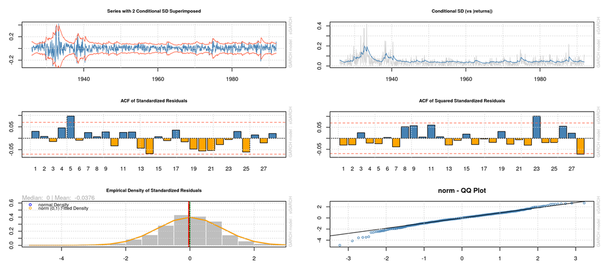

```r
par(mfrow=c(3,2));par(mar=c(3,3,3,3))
plot(fit_garchm,which=1)
plot(fit_garchm,which=3)
plot(fit_garchm,which=10)
plot(fit_garchm,which=11)
plot(fit_garchm,which=8)
plot(fit_garchm,which=9)
```